# podsumowanie

Jeżeli chodzi o algorytm wyliczający wartości własne, sprawuje się on raczej gorzej.

```
Created a ba graph, with 15 nodes
```

```
<class 'networkx.utils.decorators.argmap'> compilation 12:4: FutureWarning: laplacian_matrix will return a scipy.sparse array instead of a matrix in Networkx 3.0.
```

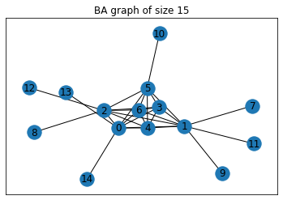

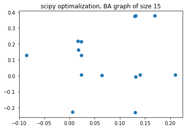

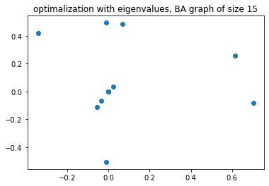

```python
graph.ba_graph(7, 15, 1)
graph.show_results("BA graph")
```

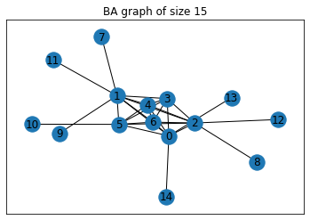

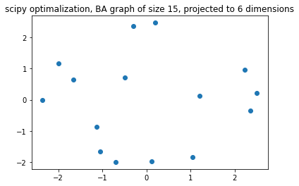

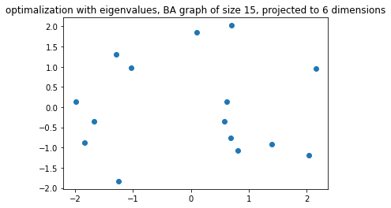

```python
graph.show_results("BA graph", 6)
```

```
<class 'networkx.utils.decorators.argmap'> compilation 12:4: FutureWarning: laplacian_matrix will return a scipy.sparse array instead of a matrix in Networkx 3.0.
```

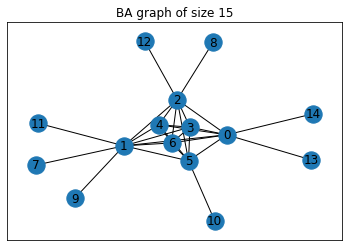

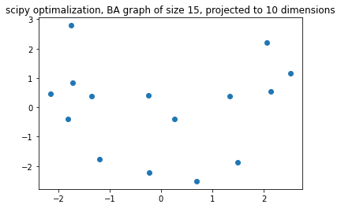

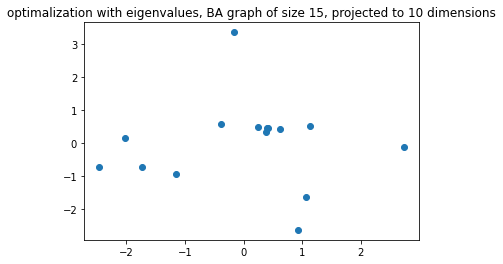

```python
graph.show_results("BA graph", 10)
```

W przypadku grafu Barabási–Alberta algorytm najlepiej sprawuje się dla d=2 - wyraźnie widać większą grupę punktów w jednym miejscu, czego nie można zaobserwować w pozostałych wizualizacjach.

W tym przypadku projekcji za pomocą wartości własnych poradziła sobie znacznie lepiej - widać strukturę grafu Barabasi-Alberta.

## Podsumowanie

W projektowaniu grafów przy użyciu algorytmu korzystającego ze scipy.optimize.minimize najlepsze wyniki są otrzymywane w ogólnym przypadku dla parametru d=2. Jeżeli chodzi o projektowanie cykli przy użyciu wyżej wspomnianego algorytmu sprawuje się on lepiej dla większych wartości d. Wydaję mi się, że jakość wyników dla d > 2 jest zmniejszona ze względu na niedokładność przeprowadzanych obliczeń i stosowane przybliżenia, które zostają dodatkowo spotęgowane przez stosowany algorytm PCA.

Mimo, to wydaje mi się, że zastosowany przeze mnie algorytm sprawuje się lepiej niż wyliczanie wyników za pomocą wartości własnych.